# Gapminder Data Analysis

##### figure 03

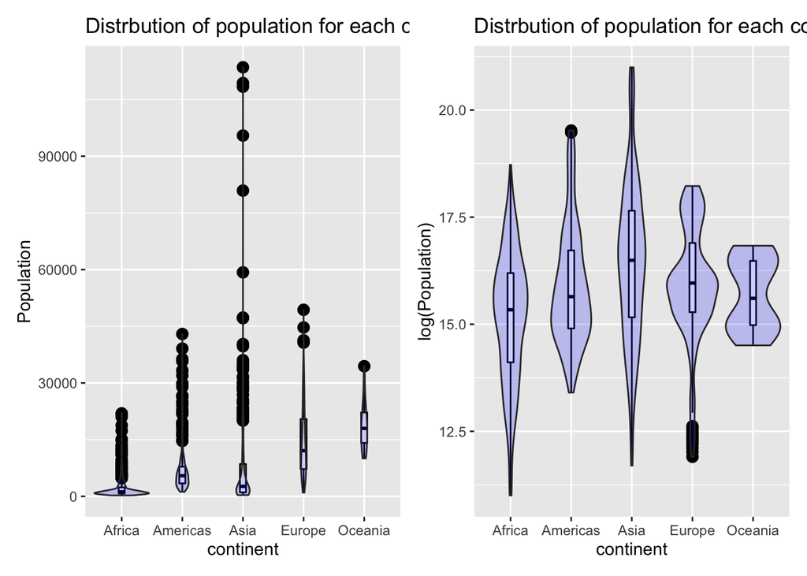

```r
p3 <- ggplot(gapminder, aes(x = continent, y = gdpPercap)) +
  geom_boxplot(outlier.size = 3, colour="black", width=0.1) +
  geom_violin(alpha = 0.2, fill = "blue") +
  ylab("Population") +
  ggtitle("Distrbution of population for each continenet")


p4 <- ggplot(gapminder, aes(x = continent, y = log(pop))) +
  geom_boxplot(outlier.size = 3, colour="black", width=0.1) +
  geom_violin(alpha = 0.2, fill = "blue") +
  ylab("log(Population)") +
  ggtitle("Distrbution of population for each continenet")

p3|p4
```

In this case also we cannot see any distributions, so we can use the log transformation for population. There is a bimodal distribution for both Europe and Oceania. There might be an external factor that affects them.

#####figure 04

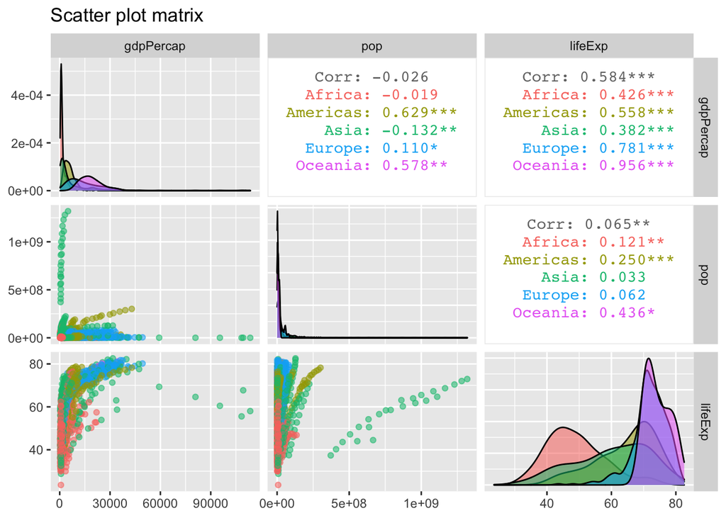

```r
ggpairs(gapminder, mapping = aes(color=continent, alpha =0.2),
        columns =c ("gdpPercap", "pop", "lifeExp"))+
  ggtitle("Scatter plot matrix")
```

There is a strong positive linear relationship between GDP per capital and life expectancy in Oceania. There is an overall weak negative linear relationship between Population and GDP per capital, but in America and Oceania has a moderate positive linear relationship. Population and life Expectancy have weak, strong linear relationships, but Oceania has a moderate linear relationship.